# Self-Driving Car Engineer Nanodegree

### Output Top 5 Softmax Probabilities For Each Image Found on the Web

For each of the new images, print out the model's softmax probabilities to show the **certainty** of the model's predictions (limit the output to the top 5 probabilities for each image). [`tf.nn.top_k`](https://www.tensorflow.org/versions/r0.12/api_docs/python/nn.html#top_k) could prove helpful here.

The example below demonstrates how tf.nn.top_k can be used to find the top k predictions for each image.

`tf.nn.top_k` will return the values and indices (class ids) of the top k predictions. So if k=3, for each sign, it'll return the 3 largest probabilities (out of a possible 43) and the correspoding class ids.

Take this numpy array as an example. The values in the array represent predictions. The array contains softmax probabilities for five candidate images with six possible classes. `tf.nn.top_k` is used to choose the three classes with the highest probability:

```
# (5, 6) array
a = np.array([[ 0.24879643,  0.07032244,  0.12641572,  0.34763842,  0.07893497,
         0.12789202],
       [ 0.28086119,  0.27569815,  0.08594638,  0.0178669 ,  0.18063401,
         0.15899337],
       [ 0.26076848,  0.23664738,  0.08020603,  0.07001922,  0.1134371 ,
         0.23892179],
       [ 0.11943333,  0.29198961,  0.02605103,  0.26234032,  0.1351348 ,
         0.16505091],
       [ 0.09561176,  0.34396535,  0.0643941 ,  0.16240774,  0.24206137,
         0.09155967]])
```

Running it through `sess.run(tf.nn.top_k(tf.constant(a), k=3))` produces:

```
TopKV2(values=array([[ 0.34763842,  0.24879643,  0.12789202],
       [ 0.28086119,  0.27569815,  0.18063401],
       [ 0.26076848,  0.23892179,  0.23664738],
       [ 0.29198961,  0.26234032,  0.16505091],
       [ 0.34396535,  0.24206137,  0.16240774]]), indices=array([[3, 0, 5],
       [0, 1, 4],
       [0, 5, 1],
       [1, 3, 5],
       [1, 4, 3]], dtype=int32))
```

Looking just at the first row we get `[ 0.34763842, 0.24879643, 0.12789202]`, you can confirm these are the 3 largest probabilities in `a`. You'll also notice `[3, 0, 5]` are the corresponding indices.

```
INFO:tensorflow:Restoring parameters from ./traffic_sign_classifier
TopKV2(values=array([[  9.82330024e-01,   1.76695343e-02,   4.89864249e-07,
          8.57682902e-09,   6.33522879e-09],
       [  1.00000000e+00,   4.33188832e-11,   3.83428044e-13,
          2.21373280e-14,   1.41539519e-14],
       [  9.86820996e-01,   1.29569769e-02,   1.05845182e-04,
          5.42732050e-05,   4.75366251e-05],
       [  1.00000000e+00,   1.27699723e-21,   3.81486413e-23,
          3.23481849e-23,   4.71612051e-24],
       [  8.73639047e-01,   1.24671951e-01,   1.60392153e-03,
          6.22324878e-05,   1.88578524e-05],
       [  9.99999881e-01,   4.94280208e-08,   3.66776014e-08,
          1.14083134e-08,   1.87302424e-10]], dtype=float32), indices=array([[ 1,  0, 38,  6,  5],
       [25, 36, 24, 18, 29],
       [14, 33, 36, 38, 25],
       [38, 36, 10, 20, 34],
       [23, 19, 31, 21, 11],
       [36, 25, 12, 33, 40]], dtype=int32))
```

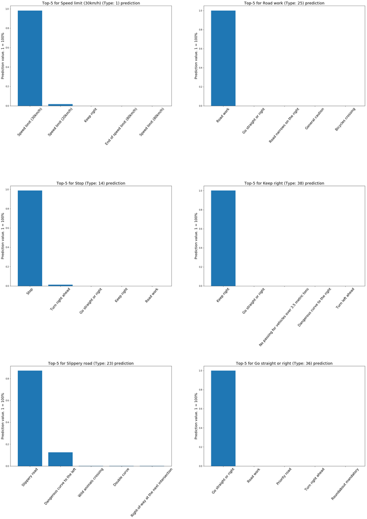

```python
# Print out the top five softmax probabilities for the predictions on the German traffic sign images found on the web.
# Feel free to use as many code cells as needed.

n = 5 # Get top n elements
softmax = tf.nn.softmax(logits)

# top_k allows us to get the top_x predicted values of the network
top_n = tf.nn.top_k(softmax, k=n)
with tf.Session() as sess:
    # Load saved model
    saver.restore(sess, tf.train.latest_checkpoint('.'))

    top_n_result = sess.run(top_n, feed_dict={x: additional_images_normed, keep_prob: 1.0})
    print(top_n_result)

if VISUALIZE_DATA:
    # Create subplots for each bar-chart to visualize the top-n predicted types
    fig, plts = plt.subplots(3,2, figsize=(30,40), gridspec_kw={'hspace': 0.8, 'wspace': .2})

    # Iterate throguh each values-set
    for i in range(len(top_n_result.values)):
        # Get the actual image type (id) and name
        actual_image_type = additional_labels[i]
        actual_image_name = getSignnameByIndex(actual_image_type)
        title = "Top-{} for {} (Type: {}) prediction".format(n, actual_image_name, actual_image_type)

        # Get values for each type of top_k
        values = top_n_result.values[i]

        # Iterate through the sign-types (ids) returned by top_k and store their actual labels
        top_predicted_signnames = []
        for signtype_id in top_n_result.indices[i]:
            top_predicted_signnames.append(getSignnameByIndex(signtype_id))

        # Visualize the top_k predictions for each predicted traffic sign in a bar-chart.
        index = np.arange(len(top_predicted_signnames))
        plts[i // 2][i % 2].bar(index, values)
        plts[i // 2][i % 2].set_ylabel('Prediction value. 1 = 100%', fontsize=16)
        plts[i // 2][i % 2].set_xticks(index) # Somehow without setting the xticks, the first column was missing https://stackoverflow.com/questions/43673659/matplotlib-not-showing-first-label-on-x-axis-for-the-bar-plot/43674299
        plts[i // 2][i % 2].set_xticklabels(top_predicted_signnames, rotation=50, fontsize=16)
        plts[i // 2][i % 2].set_title(title, fontsize=18)

    fig.savefig("./figures/top_n_prediction_for_additional_trafficsigns_barchart.png")
```

### Project Writeup

Once you have completed the code implementation, document your results in a project writeup using this [template](https://github.com/udacity/CarND-Traffic-Sign-Classifier-Project/blob/master/writeup_template.md) as a guide. The writeup can be in a markdown or pdf file.

## Step 4 (Optional): Visualize the Neural Network's State with Test Images

This Section is not required to complete but acts as an additional excersise for understaning the output of a neural network's weights. While neural networks can be a great learning device they are often referred to as a black box. We can understand what the weights of a neural network look like better by plotting their feature maps. After successfully training your neural network you can see what it's feature maps look like by plotting the output of the network's weight layers in response to a test stimuli image. From these plotted feature maps, it's possible to see what characteristics of an image the network finds interesting. For a sign, maybe the inner network feature maps react with high activation to the sign's boundary outline or to the contrast in the sign's painted symbol.

Provided for you below is the function code that allows you to get the visualization output of any tensorflow weight layer you want. The inputs to the function should be a stimuli image, one used during training or a new one you provided, and then the tensorflow variable name that represents the layer's state during the training process, for instance if you wanted to see what the LeNet lab's feature maps looked like for it's second convolutional layer you could enter conv2 as the tf_activation variable.

For an example of what feature map outputs look like, check out NVIDIA's results in their paper [End-to-End Deep Learning for Self-Driving Cars](https://devblogs.nvidia.com/parallelforall/deep-learning-self-driving-cars/) in the section Visualization of internal CNN State. NVIDIA was able to show that their network's inner weights had high activations to road boundary lines by comparing feature maps from an image with a clear path to one without. Try experimenting with a similar test to show that your trained network's weights are looking for interesting features, whether it's looking at differences in feature maps from images with or without a sign, or even what feature maps look like in a trained network vs a completely untrained one on the same sign image.

[figure not shown]

Your output should look something like this (above)

```python
### Visualize your network's feature maps here.
### Feel free to use as many code cells as needed.

# image_input: the test image being fed into the network to produce the feature maps
# tf_activation: should be a tf variable name used during your training procedure that represents the calculated state of a specific weight layer
# activation_min/max: can be used to view the activation contrast in more detail, by default matplot sets min and max to the actual min and max values of the output
# plt_num: used to plot out multiple different weight feature map sets on the same block, just extend the plt number for each new feature map entry

def outputFeatureMap(image_input, tf_activation, activation_min=-1, activation_max=-1 ,plt_num=1):
    # Here make sure to preprocess your image_input in a way your network expects
    # with size, normalization, ect if needed
    # image_input =
    # Note: x should be the same name as your network's tensorflow data placeholder variable
    # If you get an error tf_activation is not defined it may be having trouble accessing the variable from inside a function
    activation = tf_activation.eval(session=sess,feed_dict={x : image_input})
    featuremaps = activation.shape[3]
    plt.figure(plt_num, figsize=(15,15))
    for featuremap in range(featuremaps):
        plt.subplot(6,8, featuremap+1) # sets the number of feature maps to show on each row and column
        plt.title('FeatureMap ' + str(featuremap)) # displays the feature map number
        if activation_min != -1 & activation_max != -1:
            plt.imshow(activation[0,:,:, featuremap], interpolation="nearest", vmin =activation_min, vmax=activation_max, cmap="gray")
        elif activation_max != -1:
            plt.imshow(activation[0,:,:, featuremap], interpolation="nearest", vmax=activation_max, cmap="gray")
        elif activation_min !=-1:
            plt.imshow(activation[0,:,:, featuremap], interpolation="nearest", vmin=activation_min, cmap="gray")
        else:
            plt.imshow(activation[0,:,:, featuremap], interpolation="nearest", cmap="gray")
```